# Riff on Blood Pressure and Dosage Notebook

# Introduction

Sarah’s post for Discussion A on use of linearity for drug effects intrigued me.

# Packages

We load the required packages.

```r
library(tidyverse) # used to manipulate data and plot
library(ggfortify) # some extra ggplot functions
library(GGally) # pairs ggplot and other options
library(car) # many added features for regressions
library(flextable)
library(MASS) # Boston data
library(ISLR, verbose=FALSE, quietly=TRUE) # most data
```

# Data

First the raw data.

```r
Dose= c(2.5,5,10,20, 40,60)
Reduction = c(5.7, 6.4, 8.45,9.5,12,12.5)
```

Put into a data frame.

```r
sarah = data.frame(Dose=Dose, BPRed = Reduction)
```

Make the graph to check.

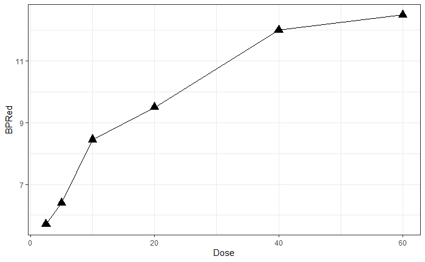

```r
ggplot(sarah) +
  geom_point(aes(Dose, BPRed), shape="triangle", size=4)+
  geom_line(aes(Dose, BPRed))+
  theme_bw()
```

Now plot the Reduxction vs log of Dose.

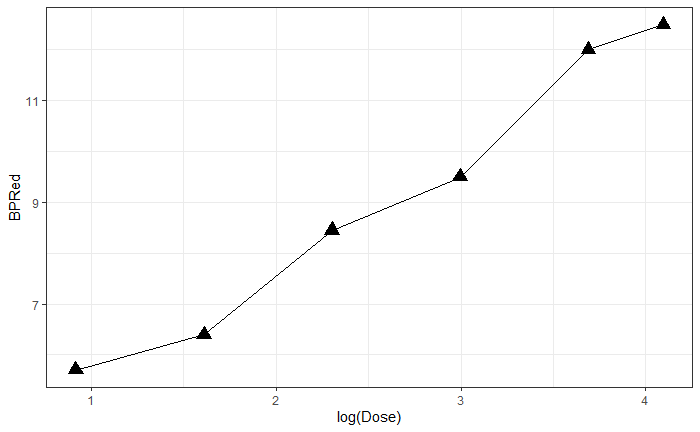

```r
ggplot(sarah) +
  geom_point(aes(log(Dose), BPRed), shape="triangle", size=4)+
  geom_line(aes(log(Dose), BPRed))+
  theme_bw()
```

Much straighter. The transformation of Dose fixed it.

Let’s check the residuals by running regressions in both cases.

```r
sarah.fit = lm(BPRed~Dose, data=sarah)
summary(sarah.fit) %>% broom::tidy()
```

| term | estimate | std.error | statistic | p.value |
| --- | --- | --- | --- | --- |
| (Intercept) | 6.421417 | 0.63602459 | 10.096177 | 0.000541552 |
| Dose | 0.116520 | 0.02057903 | 5.662074 | 0.004796600 |

```r
summary(sarah.fit) %>% broom::glance()
```

| r.squared | adj.r.squared | sigma | statistic | p.value | df | df.residual | nobs |
| --- | --- | --- | --- | --- | --- | --- | --- |
| 0.8890709 | 0.8613387 | 1.045327 | 32.05908 | 0.0047966 | 1 | 4 | 6 |

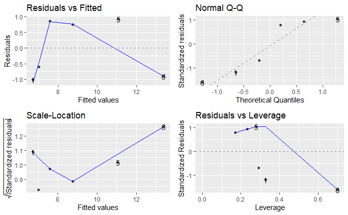

```r
autoplot(sarah.fit)
```

```r
sarah.logfit = lm(BPRed~log(Dose), data=sarah)
summary(sarah.logfit) %>% broom::tidy()
```

| term | estimate | std.error | statistic | p.value |
| --- | --- | --- | --- | --- |
| (Intercept) | 3.183428 | 0.4667747 | 6.820053 | 0.0024164779 |
| log(Dose) | 2.271341 | 0.1648964 | 13.774351 | 0.0001609752 |

```r
summary(sarah.logfit) %>% broom::glance()
```

| r.squared | adj.r.squared | sigma | statistic | p.value | df | df.residual | nobs |
| --- | --- | --- | --- | --- | --- | --- | --- |
| 0.979353 | 0.9741913 | 0.4509808 | 189.7327 | 0.0001609752 | 1 | 4 | 6 |

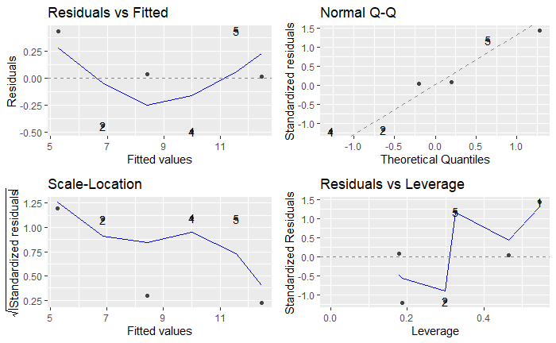

```r
autoplot(sarah.logfit)
```

# Discussion

The transform makes the regression a much higher quality one, with much less variation in hte residuals, and much more predictive power. So using the log transform is a good tool for removing the problems.

# More Insight

Why does this work? Let’s examine the original data.

```r
Dose %>% as_tibble_col(column_name="Dose") %>% flextable()
```

| Dose |
| --- |
| 2.5 |
| 5.0 |
| 10.0 |
| 20.0 |
| 40.0 |
| 60.0 |

As is common in medical experiments to find a proper dosage the dosage was approximately doubled for each level. I maybe made a mistake looking at the original graph in picking out a dose of 4 for the first point. Perhaps it was 2.5, if so it’s a direct doubling. So that is an exponential increase. Therefore taking the log of Dose makes it into a linear variable!!!!!

And we saw that a residual graph that looks like a kind of hump shape

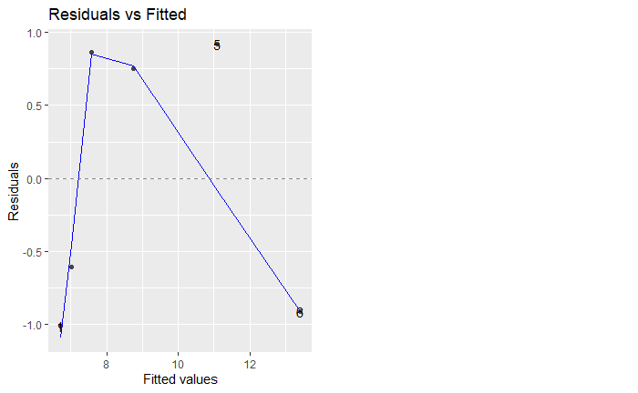

```r
autoplot(sarah.fit, which=1)
```

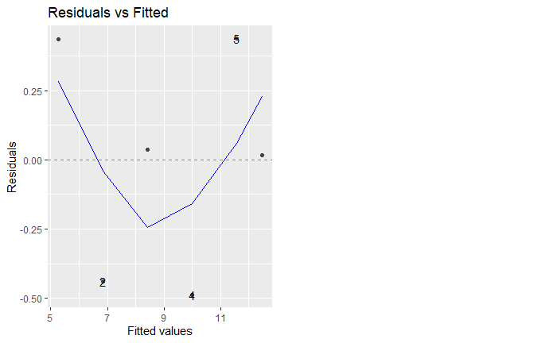

```r
autoplot(sarah.logfit, which=1)
```

# Conclusion

We can learn a lot about transforms with a little exploration.